# **Import Libraries**

```python
#yfinance is a library that uses API calls from Yahoo Finance.
#During live hours it updates as muchas the yahoo website does which is sufficient for our purposes.
! pip install yfinance
import yfinance as yf

! pip install yahoofinancials
from yahoofinancials import YahooFinancials

#we install matplotlib to get more visualisation
! pip install matplotlib pendulum
import pendulum

#allows us to present data in a clean format
!pip install mplfinance
import mplfinance as mpf
```

[output not shown]

# **Getting the past years of Stock data from Alpha Vantage**

You can use the below code to get the Financial statements (Income, Balance, Cash Flow) for the various companies you are interested in if you are willing to pay for the premium service.

```python
import requests
import json

#alpha_vantage_api_key = <You can get a free key from Alpha Vantage>

#For premium accounts, you can follow below code to make multiple api calls across multiple stocks
#We wish to extract the income statement, the balance sheets, and the statement of cash flow
financial_statements = ["INCOME_STATEMENT", "BALANCE_SHEET", "CASH_FLOW"]
stocks = ["APPL", "META"]

urls_list = ["https://www.alphavantage.co/query?function="+ statement + "&symbol="+ ticker + "&apikey="+ alpha_vantage_api_key for ticker in stocks for statement in financial_statements]
data = [requests.get(url).json() for url in urls_list]

#formattd_json so that it is in an easier format to read
formatted_json = json.dumps(data, indent=4)

print(formatted_json)
```

[output not shown]

Otherwise, do note that for their free service, there is a limit on the number of API calls you can make within certain time periods. As such, if you are using the free service, I suggest using the code below and zoning in on certain parts of the Financial Statements you are interested in for a particular stock.

```python
import requests
import json

#alpha_vantage_api_key = <You can get a free key from Alpha Vantage>

financial_statements = "INCOME_STATEMENT"
stocks = "AAPL"

url_income_statement = "https://www.alphavantage.co/query?function="+ financial_statements + "&symbol="+ stocks + "&apikey="+ alpha_vantage_api_key
requests_json_income_statement = requests.get(url_income_statement).json()

#formattd_json so that it is in an easier format to read
data_income_statement = json.dumps(requests_json_income_statement, indent=4)

print(data_income_statement)
```

```
{
    "symbol": "AAPL",
    "annualReports": [
        {
            "fiscalDateEnding": "2022-09-30",
            "reportedCurrency": "USD",
            "grossProfit": "170782000000",
            "totalRevenue": "391397000000",
            "costOfRevenue": "248640000000",
            "costofGoodsAndServicesSold": "223546000000",
            "operatingIncome": "119437000000",
            "sellingGeneralAndAdministrative": "25094000000",
            "researchAndDevelopment": "26251000000",
            "operatingExpenses": "51345000000",
            "investmentIncomeNet": "2825000000",
            "netInterestIncome": "-2931000000",
            "interestIncome": "106000000",
            "interestExpense": "2931000000",
            "nonInterestIncome": "394328000000",
            "otherNonOperatingIncome": "-228000000",
            "depreciation": "8700000000",
            "depreciationAndAmortization": "11104000000",
            "incomeBeforeTax": "119103000000",
            "incomeTaxExpense": "19300000000",
            "interestAndDebtExpense": "2931000000",
            "netIncomeFromContinuingOperations": "99803000000",
            "comprehensiveIncomeNetOfTax": "88531000000",
            "ebit": "122034000000",
            "ebitda": "130541000000",
            "netIncome": "99803000000"
        },
        {
            "fiscalDateEnding": "2021-09-30",
            "reportedCurrency": "USD",
            "grossProfit": "152836000000",
            "totalRevenue": "363172000000",
            "costOfRevenue": "234954000000",
            "costofGoodsAndServicesSold": "212981000000",
            "operatingIncome": "108949000000",
            "sellingGeneralAndAdministrative": "21973000000",
```

[output cut: 652 more lines]

```
            "nonInterestIncome": "62900000000",
            "otherNonOperatingIncome": "-140000000",
            "depreciation": "None",
            "depreciationAndAmortization": "2754000000",
            "incomeBeforeTax": "16421000000",
            "incomeTaxExpense": "2296000000",
            "interestAndDebtExpense": "868000000",
            "netIncomeFromContinuingOperations": "24084000000",
            "comprehensiveIncomeNetOfTax": "13782000000",
            "ebit": "17289000000",
            "ebitda": "18872000000",
            "netIncome": "14125000000"
        }
    ]
}
```

# **Save the output as as file to reduce number of api calls needed**

```python
jsonString = json.dumps(data)
jsonFile = open("data.json", "w")
jsonFile.write(jsonString)
jsonFile.close()
```

# **We want to get the below information from the quarterly Income Statement report**

```python
 quarterly_income = [(report["fiscalDateEnding"],
                     report["netIncome"],
                     report["grossProfit"],
                     report["totalRevenue"],
                     report["costofGoodsAndServicesSold"],
                     report["operatingIncome"],
                     report["sellingGeneralAndAdministrative"],
                     report["researchAndDevelopment"],
                     report["operatingExpenses"],
                     report["interestExpense"],
                     report["depreciation"],
                     report["incomeBeforeTax"]
                    ) for report in requests_json_income_statement["quarterlyReports"]]
```

```python
#convert the list into a pandas dataframe

import pandas as pd
df_income_statement = pd.DataFrame(quarterly_income, columns = ["fiscalDateEnding",
                                                                "netIncome",
                                                                "grossProfit",
                                                                "totalRevenue",
                                                                "costofGoodsAndServicesSold",
                                                                "operatingIncome",
                                                                "sellingGeneralAndAdministrative",
                                                                "researchAndDevelopment",
                                                                "operatingExpenses",
                                                                "interestExpense",
                                                                "depreciation",
                                                                "incomeBeforeTax"])

# Sort the DataFrame by the fiscalDateEnding column
df_sorted_income_statement = df_income_statement.sort_values(by="fiscalDateEnding")

#Currently python is viewing the values as string; hence need to convert values to integers
columns_to_convert = ["netIncome",
                      "grossProfit",
                      "totalRevenue",
                      "costofGoodsAndServicesSold",
                      "operatingIncome",
                      "sellingGeneralAndAdministrative",
                      "researchAndDevelopment",
                      "operatingExpenses",
                      "interestExpense",
                      "depreciation",
                      "incomeBeforeTax"]#,
                      #"grossProfitMargin"]

#In case of nan values, fill it as integer 0
for col in columns_to_convert:
    df_sorted_income_statement[col] = pd.to_numeric(df_sorted_income_statement[col], errors='coerce').fillna(0).astype(int)
```

# **For a company to have sustained competive advantage, gross profit margins (>40%) and net income should be in a steady uptrend over a prolonged period.**

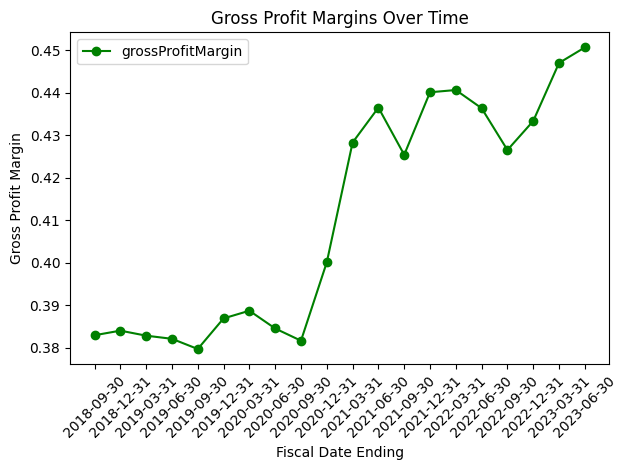

```python
#We create our own metric grossProfitMargin
df_sorted_income_statement["grossProfitMargin"] = df_sorted_income_statement["grossProfit"] / df_sorted_income_statement["totalRevenue"]

import matplotlib. pyplot as plt

plt.plot(df_sorted_income_statement["fiscalDateEnding"], df_sorted_income_statement["grossProfit"] / df_sorted_income_statement["totalRevenue"], marker='o', linestyle='-', color='g', label='grossProfitMargin')
# Set y-axis label to indicate millions
plt.ylabel("Gross Profit Margin")

plt.xlabel("Fiscal Date Ending")
plt.title("Gross Profit Margins Over Time")
plt.xticks(rotation=45)
plt.legend()  # Show legend with labels
plt.tight_layout()

# Show the graph
plt.show()
```

[figure not shown]

```python
import matplotlib.pyplot as plt
import matplotlib.ticker as ticker

# Create a line graph
plt.figure(figsize=(10, 6))
plt.plot(df_sorted_income_statement["fiscalDateEnding"], df_sorted_income_statement["netIncome"], marker='o', linestyle='-', color='b', label='netIncome')
plt.plot(df_sorted_income_statement["fiscalDateEnding"], df_sorted_income_statement["grossProfit"], marker='o', linestyle='-', color='r', label='Gross Revenue')

# Set y-axis label to indicate millions
plt.ylabel("Values (in USD)")

plt.xlabel("Fiscal Date Ending")
plt.title("Net Income and Total Revenue Over Time")
plt.xticks(rotation=45)
plt.legend()  # Show legend with labels
plt.tight_layout()

# Show the graph
plt.show()
```

# **SGA/Gross Profits should be consistent year on year**

[figure not shown]

```python
#We create our own metric grossProfitMargin
df_sorted_income_statement["SGA/grossProfit"] = df_sorted_income_statement["sellingGeneralAndAdministrative"] / df_sorted_income_statement["grossProfit"]

plt.plot(df_sorted_income_statement["fiscalDateEnding"], df_sorted_income_statement["SGA/grossProfit"], marker='o', linestyle='-', color='g', label='grossProfitMargin')
# Set y-axis label to indicate millions
plt.ylabel("SGA/grossProfit")

plt.xlabel("Fiscal Date Ending")
plt.title("SGA/grossProfit Over Time")
plt.xticks(rotation=45)
plt.legend()  # Show legend with labels
plt.tight_layout()

# Show the graph
plt.show()
```

# **Interest/operating income < 15%**

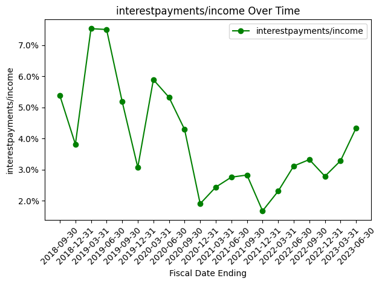

```python
#We create our own metric grossProfitMargin
df_sorted_income_statement["interestpayments/income"] = df_sorted_income_statement["interestExpense"] / df_sorted_income_statement["operatingIncome"]

plt.plot(df_sorted_income_statement["fiscalDateEnding"], df_sorted_income_statement["interestpayments/income"], marker='o', linestyle='-', color='g', label='interestpayments/income')
# Set y-axis label to indicate millions
plt.ylabel("interestpayments/income")

plt.xlabel("Fiscal Date Ending")
plt.title("interestpayments/income Over Time")
plt.xticks(rotation=45)
plt.legend()  # Show legend with labels
plt.tight_layout()

# Format y-axis labels as percentages
plt.gca().yaxis.set_major_formatter(ticker.PercentFormatter(xmax=1.0, decimals=1))

# Show the graph
plt.show()
```

**You can continue this process to evaluate the Balance Sheet and Cash Flow to further evaluate if the stock is worth buying.**

**Now, a lot of my friends buy both the S&P and the QQQ. As such, we are going to look at how we can evaluate ETFs to find out more about these 2 ETFs and see if they have substantial overlap**

```python
msft=yf.Ticker("MSFT")
```

```python
msft.history(period="max")
```

| Date | Open | High | Low | Close | Volume | Dividends | Stock Splits |
| --- | --- | --- | --- | --- | --- | --- | --- |
| 1986-03-13 | 0.055536 | 0.063703 | 0.055536 | 0.060980 | 1031788800 | 0.0 | 0.0 |
| 1986-03-14 | 0.060980 | 0.064247 | 0.060980 | 0.063158 | 308160000 | 0.0 | 0.0 |
| 1986-03-17 | 0.063158 | 0.064792 | 0.063158 | 0.064247 | 133171200 | 0.0 | 0.0 |
| 1986-03-18 | 0.064247 | 0.064792 | 0.062069 | 0.062613 | 67766400 | 0.0 | 0.0 |
| 1986-03-19 | 0.062613 | 0.063158 | 0.060980 | 0.061524 | 47894400 | 0.0 | 0.0 |
| ... | ... | ... | ... | ... | ... | ... | ... |
| 2022-10-03 | 235.410004 | 241.610001 | 234.660004 | 240.740005 | 28880400 | 0.0 | 0.0 |
| 2022-10-04 | 245.089996 | 250.360001 | 244.979996 | 248.880005 | 34888400 | 0.0 | 0.0 |
| 2022-10-05 | 245.990005 | 250.580002 | 244.100006 | 249.199997 | 20347100 | 0.0 | 0.0 |
| 2022-10-06 | 247.929993 | 250.339996 | 246.080002 | 246.789993 | 20239900 | 0.0 | 0.0 |
| 2022-10-07 | 240.899994 | 241.320007 | 233.169998 | 234.240005 | 37732400 | 0.0 | 0.0 |

9219 rows × 7 columns

```python
msft.financials
```

|  | 2022-06-30 | 2021-06-30 | 2020-06-30 | 2019-06-30 |
| --- | --- | --- | --- | --- |
| Research Development | 24512000000.0 | 20716000000.0 | 19269000000.0 | 16876000000.0 |
| Effect Of Accounting Charges | None | None | None | None |
| Income Before Tax | 83716000000.0 | 71102000000.0 | 53036000000.0 | 43688000000.0 |
| Minority Interest | None | None | None | None |
| Net Income | 72738000000.0 | 61271000000.0 | 44281000000.0 | 39240000000.0 |
| Selling General Administrative | 27725000000.0 | 25224000000.0 | 24709000000.0 | 23098000000.0 |
| Gross Profit | 135620000000.0 | 115856000000.0 | 96937000000.0 | 82933000000.0 |
| Ebit | 83383000000.0 | 69916000000.0 | 52959000000.0 | 42959000000.0 |
| Operating Income | 83383000000.0 | 69916000000.0 | 52959000000.0 | 42959000000.0 |
| Other Operating Expenses | None | None | None | None |
| Interest Expense | -2047000000.0 | -2330000000.0 | -2591000000.0 | -2686000000.0 |
| Extraordinary Items | None | None | None | None |
| Non Recurring | None | None | None | None |
| Other Items | None | None | None | None |
| Income Tax Expense | 10978000000.0 | 9831000000.0 | 8755000000.0 | 4448000000.0 |
| Total Revenue | 198270000000.0 | 168088000000.0 | 143015000000.0 | 125843000000.0 |
| Total Operating Expenses | 114887000000.0 | 98172000000.0 | 90056000000.0 | 82884000000.0 |
| Cost Of Revenue | 62650000000.0 | 52232000000.0 | 46078000000.0 | 42910000000.0 |
| Total Other Income Expense Net | 333000000.0 | 1186000000.0 | 77000000.0 | 729000000.0 |
| Discontinued Operations | None | None | None | None |
| Net Income From Continuing Ops | 72738000000.0 | 61271000000.0 | 44281000000.0 | 39240000000.0 |
| Net Income Applicable To Common Shares | 72738000000.0 | 61271000000.0 | 44281000000.0 | 39240000000.0 |

```python
print(yf.Ticker("GOOGL").shares)
```

```
      BasicShares
Year
2018  13901396520
2019  13851914459
2020  13616313872
2021  13352993991
```

**Other information we can quickly get from the library**

```python
msft = yf.Ticker("MSFT")

# get stock info
msft.info

# get historical market data
hist = msft.history(period="max")

# show actions (dividends, splits)
msft.actions

# show dividends
msft.dividends

# show splits
msft.splits

# show financials
msft.financials
msft.quarterly_financials

# show major holders
msft.major_holders

# show institutional holders
msft.institutional_holders

# show balance sheet
msft.balance_sheet
msft.quarterly_balance_sheet

# show cashflow
msft.cashflow
msft.quarterly_cashflow

# show all earnings dates
msft.earnings_dates

# show ISIN code - *experimental*
# ISIN = International Securities Identification Number
msft.isin

# show options expirations
msft.options

# show news
msft.news
```

[output not shown]

[output cut: 104 more lines]

[output not shown]

# **ETFs**

**For ETFs, let us look at 2 of the most popular ETFs: QQQ and VOO, and look at what information yfinance provides us.**

```python
yf.Ticker('QQQ').info
```

```
{'exchange': 'NGM',
 'shortName': 'Invesco QQQ Trust, Series 1',
 'longName': 'Invesco QQQ Trust',
 'exchangeTimezoneName': 'America/New_York',
 'exchangeTimezoneShortName': 'EDT',
 'isEsgPopulated': False,
 'gmtOffSetMilliseconds': '-14400000',
 'quoteType': 'ETF',
 'symbol': 'QQQ',
 'messageBoardId': 'finmb_8108558',
 'market': 'us_market',
 'annualHoldingsTurnover': None,
 'enterpriseToRevenue': None,
 'beta3Year': 1.08,
 'profitMargins': None,
 'enterpriseToEbitda': None,
 '52WeekChange': None,
 'morningStarRiskRating': None,
 'forwardEps': None,
 'revenueQuarterlyGrowth': None,
 'fundInceptionDate': 921024000,
 'annualReportExpenseRatio': None,
 'totalAssets': 169488711680,
 'bookValue': None,
 'fundFamily': 'Invesco',
 'lastFiscalYearEnd': None,
 'netIncomeToCommon': None,
 'trailingEps': None,
 'lastDividendValue': None,
 'SandP52WeekChange': None,
 'priceToBook': None,
 'nextFiscalYearEnd': None,
 'yield': 0.0062,
 'mostRecentQuarter': None,
 'enterpriseValue': None,
 'priceHint': 2,
 'threeYearAverageReturn': 0.1967,
 'lastSplitDate': None,
 'lastSplitFactor': None,
 'legalType': 'Exchange Traded Fund',
```

[output cut: 116 more lines]

```
  'priceToEarningsCat': None,
  'medianMarketCapCat': None,
  'threeYearEarningsGrowthCat': None,
  'threeYearEarningsGrowth': None,
  'medianMarketCap': None,
  'priceToEarnings': 33.89,
  'priceToBook': 8.93,
  'priceToSalesCat': None,
  'priceToCashflowCat': None},
 'otherPosition': None,
 'cashPosition': None,
 'stockPosition': 1,
 'regularMarketPrice': 308.28,
 'preMarketPrice': 307.77,
 'logo_url': ''}
```

```python
yf.Ticker('VOO').info
```

```
{'exchange': 'PCX',
 'shortName': 'Vanguard S&P 500 ETF',
 'longName': 'Vanguard 500 Index Fund',
 'exchangeTimezoneName': 'America/New_York',
 'exchangeTimezoneShortName': 'EDT',
 'isEsgPopulated': False,
 'gmtOffSetMilliseconds': '-14400000',
 'quoteType': 'ETF',
 'symbol': 'VOO',
 'messageBoardId': 'finmb_28117396',
 'market': 'us_market',
 'annualHoldingsTurnover': None,
 'enterpriseToRevenue': None,
 'beta3Year': 1,
 'profitMargins': None,
 'enterpriseToEbitda': None,
 '52WeekChange': None,
 'morningStarRiskRating': None,
 'forwardEps': None,
 'revenueQuarterlyGrowth': None,
 'fundInceptionDate': 1283817600,
 'annualReportExpenseRatio': None,
 'totalAssets': 760055005184,
 'bookValue': None,
 'fundFamily': 'Vanguard',
 'lastFiscalYearEnd': None,
 'netIncomeToCommon': None,
 'trailingEps': None,
 'lastDividendValue': None,
 'SandP52WeekChange': None,
 'priceToBook': None,
 'nextFiscalYearEnd': None,
 'yield': 0.0143,
 'mostRecentQuarter': None,
 'enterpriseValue': None,
 'priceHint': 2,
 'threeYearAverageReturn': 0.1468,
 'lastSplitDate': None,
 'lastSplitFactor': None,
 'legalType': 'Exchange Traded Fund',
```

[output cut: 120 more lines]

```
  'priceToEarningsCat': None,
  'medianMarketCapCat': None,
  'threeYearEarningsGrowthCat': None,
  'threeYearEarningsGrowth': None,
  'medianMarketCap': None,
  'priceToEarnings': 26.46,
  'priceToBook': 4.42,
  'priceToSalesCat': None,
  'priceToCashflowCat': None},
 'otherPosition': None,
 'cashPosition': None,
 'stockPosition': 0.9946,
 'regularMarketPrice': 379.68,
 'preMarketPrice': 379.62,
 'logo_url': ''}
```

# **Enter the ETFs of interest**

```python
#etfs_input = input("Enter the ETF(s) that you are interested in in the format etf1_symbol, etf2_symbol...]")
#etfs = [(''.join(etfs_input.split())).upper()]
#print(etfs)
```

[output not shown]

## **We are able to get the weightage by sector for the list of ETFs as a DataFrame**

```python
etfs = ['VOO','QQQ']
sectors_info = []
sector_weightage_etf = []
holdings_weightage_etf = []

#We are creating a function that returns us nested dictionaries within a list of the sector weightage within each ETF.
def etf_sector_weightage(etfs):
    for etf in etfs:
        etf_sector_raw = yf.Ticker(etf).info['sectorWeightings']
        sector_weightage_etf.append({k:v for x in etf_sector_raw for k,v in x.items()})
    return sector_weightage_etf
```

```python
etf_sector_weightage = etf_sector_weightage(etfs)
etf_sector_weightage
```

[output not shown]

```python
#df_etf_sector_weightage = pd.DataFrame(etf_sector_weightage).T
etf_sectors_keys = [etf_sector_weightage[0].keys()]
df_etf_sectors_keys = pd.DataFrame(etf_sectors_keys).T

etf_sectors_values=[item.values() for item in etf_sector_weightage]
df_etf_sectors_values = pd.DataFrame(etf_sectors_values).T

df_etf_sectors = pd.concat([df_etf_sectors_keys, df_etf_sectors_values],axis=1)
df_etf_sectors
```

|  | 0 | 0 | 1 |
| --- | --- | --- | --- |
| 0 | realestate | 0.0291 | 0.0000 |
| 1 | consumer_cyclical | 0.1116 | 0.1604 |
| 2 | basic_materials | 0.0242 | 0.0000 |
| 3 | consumer_defensive | 0.0729 | 0.0631 |
| 4 | technology | 0.2457 | 0.4842 |
| 5 | communication_services | 0.0860 | 0.1639 |
| 6 | financial_services | 0.1306 | 0.0086 |
| 7 | utilities | 0.0243 | 0.0088 |
| 8 | industrials | 0.0823 | 0.0431 |
| 9 | energy | 0.0415 | 0.0000 |
| 10 | healthcare | 0.1422 | 0.0638 |

```python
etf_sector_columnnames = []

def etf_sect_colnames(etfs):
    for etf in etfs:
        etf_sector = "Sector weightage within " + etf + " (%)"
        etf_sector_columnnames.append(etf_sector)
    return(etf_sector_columnnames)
```

```python
sectorcolnames = etf_sect_colnames(etfs)
sectorcolnames
```

```
['Sector weightage within VOO (%)', 'Sector weightage within QQQ (%)']
```

```python
#list_etf_sectors_weightage = [df_etf_sectors_keys, df_etf_sectors_values]

df_etf_sectors.columns = ['Sector'] + sectorcolnames
df_etf_sectors[sectorcolnames] = df_etf_sectors[sectorcolnames].multiply(100).round(2)
df_etf_sectors
```

|  | Sector | Sector weightage within VOO (%) | Sector weightage within QQQ (%) |
| --- | --- | --- | --- |
| 0 | realestate | 2.91 | 0.00 |
| 1 | consumer_cyclical | 11.16 | 16.04 |
| 2 | basic_materials | 2.42 | 0.00 |
| 3 | consumer_defensive | 7.29 | 6.31 |
| 4 | technology | 24.57 | 48.42 |
| 5 | communication_services | 8.60 | 16.39 |
| 6 | financial_services | 13.06 | 0.86 |
| 7 | utilities | 2.43 | 0.88 |
| 8 | industrials | 8.23 | 4.31 |
| 9 | energy | 4.15 | 0.00 |
| 10 | healthcare | 14.22 | 6.38 |

# **We are able to get the Symbol of TopNumHoldings within each ETF as a DataFrame**

```python
#Input
top_num_holdings = 10

#This enables us to get the top holding of each etf but we want the top 10
etfs = ['VOO','QQQ']
etf_stocks_list = []
def top_etf_holdings(etfs):
    for etf in etfs:
        for x in range(top_num_holdings):
            etf_stocks_list.append(yf.Ticker(etf).info['holdings'][x]['symbol'])
    return(etf_stocks_list)
```

```python
top_etf_holdings=top_etf_holdings(etfs)
top_etf_holdings
```

```
['AAPL',
 'MSFT',
 'AMZN',
 'FB',
 'GOOGL',
 'GOOG',
 'BRK.B',
 'TSLA',
 'NVDA',
 'JPM',
 'AAPL',
 'MSFT',
 'AMZN',
 'GOOG',
 'FB',
 'TSLA',
 'GOOGL',
 'NVDA',
 'PYPL',
 'ADBE']
```

```python
#This returns us nested lists of all the holdings by ETF
def slice_etf_stocks_list(top_etf_holdings):
    return ([top_etf_holdings[i:i+top_num_holdings:1] for i in list(range(0,len(top_etf_holdings),top_num_holdings))])
```

```python
slice_etf_stocks_list = slice_etf_stocks_list(top_etf_holdings)
slice_etf_stocks_list
```

```
[['AAPL',
  'MSFT',
  'AMZN',
  'FB',
  'GOOGL',
  'GOOG',
  'BRK.B',
  'TSLA',
  'NVDA',
  'JPM'],
 ['AAPL',
  'MSFT',
  'AMZN',
  'GOOG',
  'FB',
  'TSLA',
  'GOOGL',
  'NVDA',
  'PYPL',
  'ADBE']]
```

```python
import pandas as pd
df_etf_stock_symbols=pd.DataFrame(slice_etf_stocks_list).T
df_etf_stock_symbols.columns = etfs
df_etf_stock_symbols
```

|  | VOO | QQQ |
| --- | --- | --- |
| 0 | AAPL | AAPL |
| 1 | MSFT | MSFT |
| 2 | AMZN | AMZN |
| 3 | FB | GOOG |
| 4 | GOOGL | FB |
| 5 | GOOG | TSLA |
| 6 | BRK.B | GOOGL |
| 7 | TSLA | NVDA |
| 8 | NVDA | PYPL |
| 9 | JPM | ADBE |

# **We are able to get the indv stock weightage within each ETF as a DataFrame**

```python
#We are creating a function that returns us a list of all the holdings within the ETFs we have chosen.
etf_holdings_raw = []
holding_percent = []
def etf_holdings_weightage(etfs):
    for etf in etfs:
        etf_holdings_raw = yf.Ticker(etf).info['holdings']
        for i in range(len(etf_holdings_raw)):
            holding_percent.append(etf_holdings_raw[i]['holdingPercent'])
    return(holding_percent)
```

```python
etf_holdings_weightage = etf_holdings_weightage(etfs)
etf_holdings_weightage
```

```
[0.0592,
 0.056199998,
 0.040599998,
 0.0229,
 0.0202,
 0.0197,
 0.014400001,
 0.014400001,
 0.0137,
 0.012999999,
 0.11270001,
 0.1011,
 0.0779,
 0.0419,
 0.0404,
 0.039,
 0.0387,
 0.0378,
 0.023,
 0.0215]
```

```python
#This returns us nested lists of all the holdings by ETF
def slice_weightage(etf_holdings_weightage):
    return ([etf_holdings_weightage[i:i+top_num_holdings:1] for i in list(range(0,len(etf_holdings_weightage),top_num_holdings))])

sliced_weightage_holdings = slice_weightage(etf_holdings_weightage)
```

```python
pd.DataFrame(sliced_weightage_holdings).T

etf_hw_columnnames = []

def etf_hw_colnames(etfs):
    for etf in etfs:
        etf_hw = "Stock weightage within " + etf + " (%)"
        etf_hw_columnnames.append(etf_hw)
    return(etf_hw_columnnames)
```

```python
newcolnames = etf_hw_colnames(etfs)
newcolnames
```

```
['Stock weightage within VOO (%)', 'Stock weightage within QQQ (%)']
```

```python
#Rename the columns and change the %
df_etf_stock_weightage = pd.DataFrame(sliced_weightage_holdings).T
df_etf_stock_weightage.columns = newcolnames
df_etf_stock_weightage[newcolnames] = df_etf_stock_weightage[newcolnames].multiply(100).round(2)
df_etf_stock_weightage
```

|  | Stock weightage within VOO (%) | Stock weightage within QQQ (%) |
| --- | --- | --- |
| 0 | 5.92 | 11.27 |
| 1 | 5.62 | 10.11 |
| 2 | 4.06 | 7.79 |
| 3 | 2.29 | 4.19 |
| 4 | 2.02 | 4.04 |
| 5 | 1.97 | 3.90 |
| 6 | 1.44 | 3.87 |
| 7 | 1.44 | 3.78 |
| 8 | 1.37 | 2.30 |
| 9 | 1.30 | 2.15 |

# **We combine the top stocks symbols with their respective holding weightage**

```python
df_etfs_stocks_weightages = pd.concat([df_etf_stock_symbols, df_etf_stock_weightage],axis=1)
df_etfs_stocks_weightages
```

|  | VOO | QQQ | Stock weightage within VOO (%) | Stock weightage within QQQ (%) |
| --- | --- | --- | --- | --- |
| 0 | AAPL | AAPL | 5.92 | 11.27 |
| 1 | MSFT | MSFT | 5.62 | 10.11 |
| 2 | AMZN | AMZN | 4.06 | 7.79 |
| 3 | FB | GOOG | 2.29 | 4.19 |
| 4 | GOOGL | FB | 2.02 | 4.04 |
| 5 | GOOG | TSLA | 1.97 | 3.90 |
| 6 | BRK.B | GOOGL | 1.44 | 3.87 |
| 7 | TSLA | NVDA | 1.44 | 3.78 |
| 8 | NVDA | PYPL | 1.37 | 2.30 |
| 9 | JPM | ADBE | 1.30 | 2.15 |

# **Let us reorder the columns to make it easier for comparison**

```python
names = df_etfs_stocks_weightages.columns.values
#indexes of etf names
def odd(names):
    return [i for i in range(0, len(names), 2)]
#indexes of etf values
def even(names):
    return [i for i in range(1, len(names), 2)]

new_columns_order = odd(names) + even(names)
```

```python
#rearrange order of columns
names = df_etfs_stocks_weightages.columns.tolist()
df_etfs_stocks_weightages = df_etfs_stocks_weightages.iloc[:, new_columns_order]
df_etfs_stocks_weightages
```

|  | VOO | Stock weightage within VOO (%) | QQQ | Stock weightage within QQQ (%) |
| --- | --- | --- | --- | --- |
| 0 | AAPL | 5.92 | AAPL | 11.27 |
| 1 | MSFT | 5.62 | MSFT | 10.11 |
| 2 | AMZN | 4.06 | AMZN | 7.79 |
| 3 | FB | 2.29 | GOOG | 4.19 |
| 4 | GOOGL | 2.02 | FB | 4.04 |
| 5 | GOOG | 1.97 | TSLA | 3.90 |
| 6 | BRK.B | 1.44 | GOOGL | 3.87 |
| 7 | TSLA | 1.44 | NVDA | 3.78 |
| 8 | NVDA | 1.37 | PYPL | 2.30 |
| 9 | JPM | 1.30 | ADBE | 2.15 |

# **For Individual list of stocks:**

```python
indv_stocks_list = slice_etf_stocks_list[0]
```

```python
#Input
top_num_holdings = 10

#This enables us to get the top holding of each etf but we want the top 10
indv_stocks_list = ['VOO']

stocks_list = []
def indv_stocks(indv_stocks_list):
    for indv_stock in indv_stocks_list:
        for x in range(top_num_holdings):
            stocks_list.append(yf.Ticker(indv_stock).info['holdings'][x]['symbol'])
    return(stocks_list)
```

```python
indv_stocks = indv_stocks(indv_stocks_list)
indv_stocks
```

```
['AAPL', 'MSFT', 'AMZN', 'FB', 'GOOGL', 'GOOG', 'BRK.B', 'TSLA', 'NVDA', 'JPM']
```

```python
yf.Ticker("TSLA").info
```

```
{'zip': '78725',
 'sector': 'Consumer Cyclical',
 'fullTimeEmployees': 99290,
 'longBusinessSummary': 'Tesla, Inc. designs, develops, manufactures, leases, and sells electric vehicles, and energy generation and storage systems in the United States, China, and internationally. The company operates in two segments, Automotive, and Energy Generation and Storage. The Automotive s…
 'city': 'Austin',
 'phone': '(512) 516-8177',
 'state': 'TX',
 'country': 'United States',
 'companyOfficers': [],
 'website': 'https://www.tesla.com',
 'maxAge': 1,
 'address1': '13101 Tesla Road',
 'industry': 'Auto Manufacturers',
 'ebitdaMargins': 0.20424,
 'profitMargins': 0.13505,
 'grossMargins': 0.27096,
 'operatingCashflow': 13850999808,
 'revenueGrowth': 0.805,
 'operatingMargins': 0.1549,
 'ebitda': 12702000128,
 'targetLowPrice': 67,
 'recommendationKey': 'buy',
 'grossProfits': 13606000000,
 'freeCashflow': 7054624768,
 'targetMedianPrice': 975,
 'currentPrice': 758.26,
 'earningsGrowth': 6.315,
 'currentRatio': 1.354,
 'returnOnAssets': 0.10118,
 'numberOfAnalystOpinions': 40,
 'targetMeanPrice': 928.4,
 'debtToEquity': 19.841,
 'returnOnEquity': 0.28261,
 'targetHighPrice': 1620,
 'totalCash': 18012999680,
 'totalDebt': 7024999936,
 'totalRevenue': 62189998080,
 'totalCashPerShare': 17.387,
 'financialCurrency': 'USD',
 'revenuePerShare': 61.927,
```

[output cut: 98 more lines]

```
 'askSize': 800,
 'volume': 33971457,
 'fiftyTwoWeekHigh': 1243.49,
 'fromCurrency': None,
 'fiveYearAvgDividendYield': None,
 'fiftyTwoWeekLow': 571.22,
 'bid': 0,
 'tradeable': False,
 'dividendYield': None,
 'bidSize': 3200,
 'dayHigh': 778.49,
 'regularMarketPrice': 758.26,
 'preMarketPrice': 753.4,
 'logo_url': 'https://logo.clearbit.com/tesla.com',
 'trailingPegRatio': 1.5473}
```

```python
indv_stocks
```

```
['AAPL', 'MSFT', 'AMZN', 'FB', 'GOOGL', 'GOOG', 'BRK.B', 'TSLA', 'NVDA', 'JPM']
```

```python
#Maximum is 10 if pull from yfinance for VOO/QQQ
#top_num_holdings = 10

source = []

def indv_stocks_key_metrics(indv_stocks):
    for stock in indv_stocks:
        stock_info = yf.Ticker(stock).info
        try:
            source.extend([stock, stock_info['sector'], stock_info['totalRevenue'], stock_info['currentRatio'],stock_info['earningsGrowth'],stock_info['trailingPE']])
        except KeyError:
            continue
    return source

metrics_list =['Company Name', 'Sector','Revenue','Current Ratio', 'Earnings Growth','Trailing PE']
```

```python
indv_stocks_key_metrics=indv_stocks_key_metrics(indv_stocks)
indv_stocks_key_metrics
```

```
['AAPL',
 'Technology',
 386017001472,
 0.927,
 0.086,
 24.252892,
 'MSFT',
 'Technology',
 192557006848,
 1.988,
 0.094,
 28.378914,
 'AMZN',
 'Consumer Cyclical',
 477748002816,
 0.96,
 None,
 57.668266,
 'FB',
 'Communication Services',
 119665999872,
 2.811,
 -0.176,
 14.654155,
 'GOOGL',
 'Communication Services',
 270334001152,
 2.871,
 -0.063,
 20.574581,
 'GOOG',
 'Communication Services',
 270334001152,
 2.871,
 -0.063,
 20.624678,
 'TSLA',
 'Consumer Cyclical',
 62189998080,
 1.354,
 6.315,
 102.46757,
 'NVDA',
 'Technology',
 29540999168,
 5.317,
 -0.158,
 50.072403,
 'JPM',
 'Financial Services',
 123730001920,
 None,
 -0.416,
 9.807892]
```

```python
#If we change the number of dimensions for each stock, we need to change
#num_dimensions = 6
num_dimensions = len(metrics_list)
#the number of dimensions include the name of the stock

def slice_stock_metrics(indv_stocks_key_metrics):
    slice_metrics = [indv_stocks_key_metrics[i:i+num_dimensions:1] for i in list(range(0,len(indv_stocks_key_metrics), num_dimensions))]
    return slice_metrics
```

```python
sep_stock_metrics = slice_stock_metrics(indv_stocks_key_metrics)
sep_stock_metrics
```

```
[['AAPL', 'Technology', 386017001472, 0.927, 0.086, 24.252892],
 ['MSFT', 'Technology', 192557006848, 1.988, 0.094, 28.378914],
 ['AMZN', 'Consumer Cyclical', 477748002816, 0.96, None, 57.668266],
 ['FB', 'Communication Services', 119665999872, 2.811, -0.176, 14.654155],
 ['GOOGL', 'Communication Services', 270334001152, 2.871, -0.063, 20.574581],
 ['GOOG', 'Communication Services', 270334001152, 2.871, -0.063, 20.624678],
 ['TSLA', 'Consumer Cyclical', 62189998080, 1.354, 6.315, 102.46757],
 ['NVDA', 'Technology', 29540999168, 5.317, -0.158, 50.072403],
 ['JPM', 'Financial Services', 123730001920, None, -0.416, 9.807892]]
```

```python
import pandas as pd
df_stocks_metrics = pd.DataFrame(sep_stock_metrics, columns = metrics_list)
df_stocks_metrics['Monthly Revenue (Billions)'] = df_stocks_metrics['Revenue'].div(12000000000).round(2)
df_stocks_metrics = df_stocks_metrics.drop(['Revenue'], axis = 1)
df_stocks_metrics
```

|  | Company Name | Sector | Current Ratio | Earnings Growth | Trailing PE | Monthly Revenue (Billions) |
| --- | --- | --- | --- | --- | --- | --- |
| 0 | AAPL | Technology | 0.927 | 0.086 | 24.252892 | 32.17 |
| 1 | MSFT | Technology | 1.988 | 0.094 | 28.378914 | 16.05 |
| 2 | AMZN | Consumer Cyclical | 0.960 | NaN | 57.668266 | 39.81 |
| 3 | FB | Communication Services | 2.811 | -0.176 | 14.654155 | 9.97 |
| 4 | GOOGL | Communication Services | 2.871 | -0.063 | 20.574581 | 22.53 |
| 5 | GOOG | Communication Services | 2.871 | -0.063 | 20.624678 | 22.53 |
| 6 | TSLA | Consumer Cyclical | 1.354 | 6.315 | 102.467570 | 5.18 |
| 7 | NVDA | Technology | 5.317 | -0.158 | 50.072403 | 2.46 |
| 8 | JPM | Financial Services | NaN | -0.416 | 9.807892 | 10.31 |

```python
market_price = stock_info['regularMarketPrice']
previous_close_price = stock_info['regularMarketPreviousClose']
key_interests = ['regularMarketPrice',
                'regularMarketPreviousClose']

def key_metrics():
    x = input('Input Stock Symbol of interest:')

    try:
        stock_info=yf.Ticker(x).info
    except:
        print('Stock Symbol invalid. Please re-enter:')
        #y = input('Input Stock Symbol of interest:')
        #stock_info=yf.Ticker(x).info
```

# **Visualisation & Presentation of Key Insights**

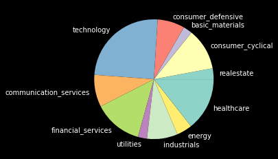

```python
voo_weightage = df_etf_sectors['Sector weightage within VOO (%)']
mylabel = df_etf_sectors['Sector']
plt.pie(voo_weightage,labels=mylabel)
plt.show()
```

# **Cleaned Master Table**

```python
df_etf_sectors
#df_etf_sectors --- Sector and sector weightage within etfs
```

|  | Sector | Sector weightage within VOO (%) | Sector weightage within QQQ (%) |
| --- | --- | --- | --- |
| 0 | realestate | 2.91 | 0.00 |
| 1 | consumer_cyclical | 11.16 | 16.04 |
| 2 | basic_materials | 2.42 | 0.00 |
| 3 | consumer_defensive | 7.29 | 6.31 |
| 4 | technology | 24.57 | 48.42 |
| 5 | communication_services | 8.60 | 16.39 |
| 6 | financial_services | 13.06 | 0.86 |
| 7 | utilities | 2.43 | 0.88 |
| 8 | industrials | 8.23 | 4.31 |
| 9 | energy | 4.15 | 0.00 |
| 10 | healthcare | 14.22 | 6.38 |

```python
df_etfs_stocks_weightages
#df_etfs_stocks_weightages --- ETFs and stock weightages
```

|  | VOO | Stock weightage within VOO (%) | QQQ | Stock weightage within QQQ (%) |
| --- | --- | --- | --- | --- |
| 0 | AAPL | 5.92 | AAPL | 11.27 |
| 1 | MSFT | 5.62 | MSFT | 10.11 |
| 2 | AMZN | 4.06 | AMZN | 7.79 |
| 3 | FB | 2.29 | GOOG | 4.19 |
| 4 | GOOGL | 2.02 | FB | 4.04 |
| 5 | GOOG | 1.97 | TSLA | 3.90 |
| 6 | BRK.B | 1.44 | GOOGL | 3.87 |
| 7 | TSLA | 1.44 | NVDA | 3.78 |
| 8 | NVDA | 1.37 | PYPL | 2.30 |
| 9 | JPM | 1.30 | ADBE | 2.15 |

```python
#df_etf_stock_symbols.drop(columns=df_etf_stock_symbols.columns[2], axis=1, inplace=True)
df_etf_stock_symbols
slice_etf_stocks_list

#df_etf_stock_symbols['unique'] = df_etf_stock_symbols.isin(df_etf_stock_symbols.pop('VOO').values.tolist()).all(axis=1)
```

```python
df_etf_stock_symbols
```

|  | VOO | QQQ |
| --- | --- | --- |
| 0 | AAPL | AAPL |
| 1 | MSFT | MSFT |
| 2 | AMZN | AMZN |
| 3 | FB | GOOG |
| 4 | GOOGL | FB |
| 5 | GOOG | TSLA |
| 6 | BRK.B | GOOGL |
| 7 | TSLA | NVDA |
| 8 | NVDA | PYPL |
| 9 | JPM | ADBE |

```python
slice_etf_stocks_list[0]

unique_check0 = []
unique_check1 = []

def unique0(slice_etf_stocks_list):
    [unique_check0.append(True) if i in slice_etf_stocks_list[1] else unique_check0.append(False) for i in slice_etf_stocks_list[0]]
    return unique_check0

def unique1(slice_etf_stocks_list):
    [unique_check1.append(True) if i in slice_etf_stocks_list[0] else unique_check1.append(False) for i in slice_etf_stocks_list[1]]
    return unique_check1
```

```python
#print(unique0(slice_etf_stocks_list))
#print(unique1(slice_etf_stocks_list))

df_etfs_stocks_weightages['col0'] = unique0(slice_etf_stocks_list)
df_etfs_stocks_weightages['col2'] = unique1(slice_etf_stocks_list)
```

```python
em = []
for i,v in enumerate(unique0(slice_etf_stocks_list)):
    if v is False:
        em.append(i)
```

```python
#we know the index that is false, this should tally with the index of the stocks we want

print("These are the stocks within", etfs[0], "that are unique")
df_etfs_stocks_weightages.iloc[em,[0,1]]
df_etfs_stocks_weightages.iloc[em,[0,1]]

#df_etf_stock_symbols.loc[df_etf_stock_symbols['VOO'].notin(df_etf_stock_symbols["QQQ"])]
```

```
These are the stocks within VOO that are unique
```

[output not shown]

# **Stocks Time Series**

```
What stock are you interested in?
 Please enter a valid Stock Ticker Symbol such as TSLA for TeslaTSLA
Over what historical time period are you interested in?
 You may enter one of the following periods: 1d, 5d, 1mo, 3mo, 6mo, 1y, 2y, 5y, 10y, ytd, max10y
What is the interval you would like to see between each stock price?
 You may enter one of the following: 1m,2m,5m,15m,30m,60m,90m,1h,1d,5d,1wk,1mo,3mo1mo
Which price aspect are you interested in?
 You may enter one of the following: 'Open', 'High', 'Low', 'Close', 'Volume', 'Dividends', 'Stock Splits'Open
```

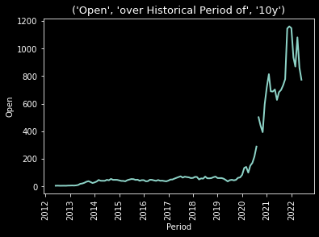

```python
import yfinance as yf
import pendulum
import matplotlib.pyplot as plt

stock = input("What stock are you interested in? \n Please enter a valid Stock Ticker Symbol such as TSLA for Tesla")
period = input("Over what historical time period are you interested in? \n You may enter one of the following periods: 1d, 5d, 1mo, 3mo, 6mo, 1y, 2y, 5y, 10y, ytd, max")
interval = input("What is the interval you would like to see between each stock price? \n You may enter one of the following: 1m,2m,5m,15m,30m,60m,90m,1h,1d,5d,1wk,1mo,3mo")
measure = input("Which price aspect are you interested in? \n You may enter one of the following: 'Open', 'High', 'Low', 'Close', 'Volume', 'Dividends', 'Stock Splits'")
#price_history.columns.values

price_history = yf.Ticker(stock).history(period=period, interval=interval)
#valid periods: 1d, 5d, 1mo, 3mo, 6mo, 1y, 2y, 5y, 10y, ytd, max
#valid intervals: #1m,2m,5m,15m,30m,60m,90m,1h,1d,5d,1wk,1mo,3mo
time_series = list(price_history[measure])
#dt_list=[pendulum.parse(str(dt)).float_timestamp for dt in list(price_history.index)]
dt_list=[pendulum.parse(str(dt)) for dt in list(price_history.index)]
#plt.style.use('dark_background')

#x axis
plt.xlabel('Period')
plt.xticks(rotation=90)

#y axis
plt.ylabel(measure)

# displaying the title
plt.title(label= (measure, "over Historical Period of", period), fontsize=13, color="white")

#print visualisation
plt.plot(dt_list,time_series,linewidth=2)
```

```python
#This allows us to capture the time taken for each function to run
import time
start_time = time.time()
pd.DataFrame(y)
print("--- %s seconds ---" % (time.time() - start_time))
```

```python
#!pip install nbconvert
#!jupyter nbconvert --to html /content/Stocks_Evaluator_GitHub.ipynb
```

[output not shown]